# Data Science Specialization - Capstone Week2

bluebonobo

2022-07-03

# Outline

This document explains the major features of the data and summarize how I plan to create a prediction algorithm and Shiny app using the knowledge acquired during the specialization. I also describe in the Appendix how I will subset the corpus going forward to allow for faster development cycles.

# Exploratory Analysis

For each file in the english language (blogs, news and twitter), we build a VCorpus object, we clean the VCorpus by removing whitepaces, convert all to lower case, remove English stop words, remove punctuation, remove numbers, remove profanity and stem. We then tokenzie and finally create a DocumentTermMatrix.

We show the top 10 words and a wordcloud for each file below.

## Blogs File Analysis

The Sample Blogs file we are going to analyze consists of **899288 lines** and **364816 terms**.

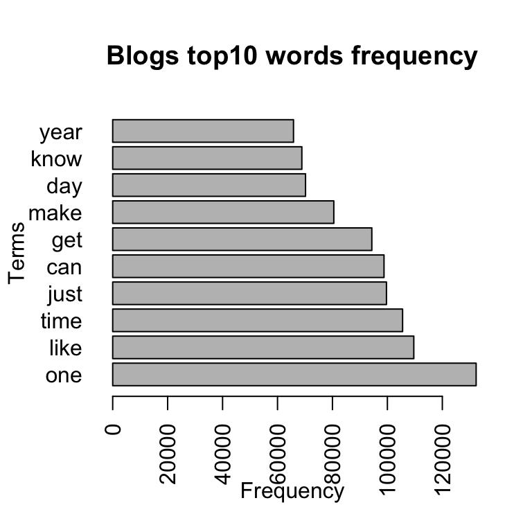

[figure not shown]

## News File Analysis

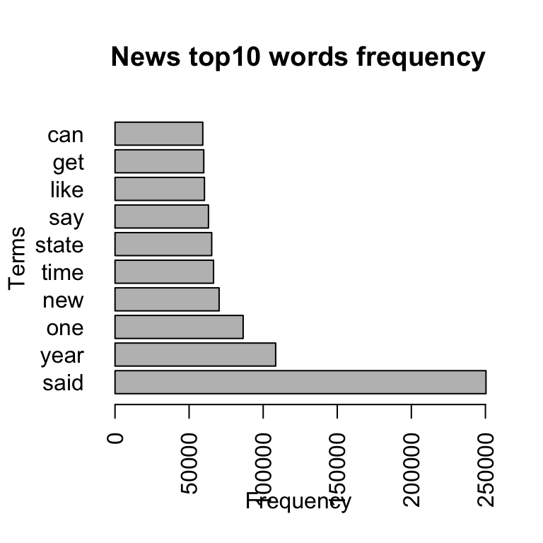

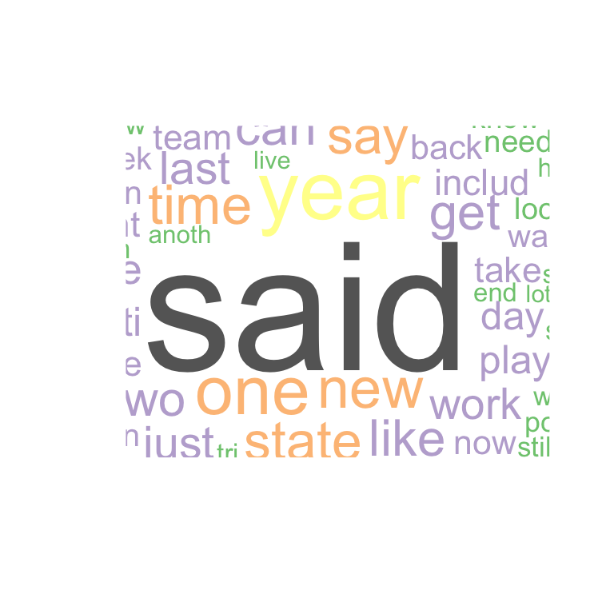